# Data Wrangling 2

## 3.1 Why tidy data?

> “**Happy families** are all alike; every **unhappy family** is unhappy in its own way.” — Leo Tolstoy

> “**Tidy datasets** are all alike, but every **untidy dataset** is untidy in its own way.” — Hadley Wickham
- Die Bereinigung der Daten erfordert im Vorfeld einige Arbeit, ist aber auf lange Sicht hilfreich
- wenn wir einmal aufgeräumte Daten haben, werden wir weniger Zeit damit verbringen, die Daten in die richtige Form zu bringen, um das zu tun, was wir wollen

Die Arbeit mit aufgeräumten Daten hat zwei wesentliche Vorteile:

1. Die Arbeit mit einer konsistenten Datenstruktur ermöglicht es uns, Konventionen zu übernehmen
   - Da aufgeräumte Daten die allgemein anerkannte Datenstruktur sind, basieren die Konventionen auf der Annahme dieser Struktur.
   - Werkzeuge haben also eine zugrundeliegende Einheitlichkeit
2. Die vektorisierte Natur von R kann glänzen
   - Die meisten eingebauten R-Funktionen arbeiten mit *Vektorwerten*.
   - Alle Pakete im `tidyverse` sind für die Arbeit mit Tidy-Daten konzipiert

**Vectors**

Vektoren sind der grundlegendste Datenobjekttyp in R. Ein Vektor enthält Daten desselben Typs und ist im Wesentlichen eine Liste. Wir können einen Vektor zum Beispiel mit der Funktion `c()` erstellen.

```r
vector1 <- c(2, 3, 4, 6, 7)
vector2 <- c(2, 3, 4, 6, "c")
```

`vector1` wird numerische Werte enthalten, da alle Elemente Zahlen sind. `vector2` enthält alle Zeichenwerte (d.h. Text), da es ein einziges eindeutiges Zeichenelement (`c()`) gibt. R liest also alle Elemente als Zeichentyp. Wir können einen Datenrahmen aus Vektoren gleicher Länge erstellen, indem wir z. B. die Funktion `tibble()` verwenden.

```r
tibble(vector1,vector2)
```

```
# A tibble: 5 × 2
  vector1 vector2
    <dbl> <chr>
1       2 2
2       3 3
3       4 4
4       6 6
5       7 c
```

- die meisten Daten “in the wild” sind unordentlich
  - Die Daten werden häufig zunächst für ein anderes Ziel als die Analyse organisiert
    - Dieses Ziel ist in der Regel die Dateneingabe: Wir wollen unsere Beobachtungen zunächst einfach dokumentieren können
  - die meisten Menschen sind nicht mit den Grundsätzen ordentlicher Daten vertraut, und erst nachdem sie *viel* Zeit mit Daten verbracht haben, wird klar, warum ordentliche Daten notwendig sind
- Dies bedeutet, dass die meisten *echten* Analysen zumindest ein gewisses Maß an Aufräumen erfordern.

**Aufgabe 1: Tidy data**

**Beispiel 1**

## 3.2 Daten aufräumen

- Umformung
  - z.B. von breiten zu langen Daten
- Ergebnis:
  - jede Spalte = eine Variable
  - jede Zeile = eine Beobachtung

### 3.2.1 Datenaufräumung mit dem `tidyverse`

- mit dem `tidyr`-Paket
  - `pivot_longer()`: macht breite Daten länger
  - `pivot_wider()`: lange Daten breiter machen
- wir müssen oft zwischen diesen Formaten konvertieren, um verschiedene Arten von Zusammenfassungen oder Visualisierungen zu erstellen

[figure not shown]

Abbildung 1: die berühmteste Verwendung des Wortes Pivot (zumindest für Millenials) ([Friends](https://www.youtube.com/watch?v=8w3wmQAMoxQ))

### 3.2.2 Breite versus lange Daten

- Breite Daten: alle Beobachtungen zu einer Sache stehen in derselben Zeile
  - breite Daten sind *normalerweise* nicht ‘tidy’
- lange Daten: jede Beobachtung steht in einer eigenen Zeile
  - lange Daten sind *in der Regel* ‘tidy’

# 4 Verlängern von Daten: `df_billboard`

- in dem Datensatz `billboard.csv`
  - jede Zeile ist ein Lied
  - die ersten drei Spalten sind Variablen, die den Song beschreiben (`artist`, `track`, `date_entered`)
  - wir haben 76 Spalten (`wk1-wk76`), die den Rang des Liedes in dieser Woche beschreiben
    - Die Spaltennamen sind eine Variable (die `week`), und die Zellwerte sind eine andere Variable (der `rank`)

```r
df_billboard %>%
  head(n = 10) %>%
  knitr::kable() %>%
  kableExtra::kable_styling(font_size = 20)
```

Tabelle 1: df_billboard rank of songs in the year 2000

| artist | track | date_entered | wk1 | wk2 | wk3 | wk4 | wk5 | wk6 | wk7 | wk8 | wk9 | wk10 | wk11 | wk12 | wk13 | wk14 | wk15 | wk16 | wk17 | wk18 | wk19 | wk20 | wk21 | wk22 | wk23 | wk24 | wk25 | wk26 | wk27 | … |
| --- | --- | --- | --- | --- | --- | --- | --- | --- | --- | --- | --- | --- | --- | --- | --- | --- | --- | --- | --- | --- | --- | --- | --- | --- | --- | --- | --- | --- | --- | --- |
| 2 Pac | Baby Don't Cry (Keep... | 2000-02-26 | 87 | 82 | 72 | 77 | 87 | 94 | 99 | NA | NA | NA | NA | NA | NA | NA | NA | NA | NA | NA | NA | NA | NA | NA | NA | NA | NA | NA | NA | … |
| 2Ge+her | The Hardest Part Of ... | 2000-09-02 | 91 | 87 | 92 | NA | NA | NA | NA | NA | NA | NA | NA | NA | NA | NA | NA | NA | NA | NA | NA | NA | NA | NA | NA | NA | NA | NA | NA | … |
| 3 Doors Down | Kryptonite | 2000-04-08 | 81 | 70 | 68 | 67 | 66 | 57 | 54 | 53 | 51 | 51 | 51 | 51 | 47 | 44 | 38 | 28 | 22 | 18 | 18 | 14 | 12 | 7 | 6 | 6 | 6 | 5 | 5 | … |
| 3 Doors Down | Loser | 2000-10-21 | 76 | 76 | 72 | 69 | 67 | 65 | 55 | 59 | 62 | 61 | 61 | 59 | 61 | 66 | 72 | 76 | 75 | 67 | 73 | 70 | NA | NA | NA | NA | NA | NA | NA | … |
| 504 Boyz | Wobble Wobble | 2000-04-15 | 57 | 34 | 25 | 17 | 17 | 31 | 36 | 49 | 53 | 57 | 64 | 70 | 75 | 76 | 78 | 85 | 92 | 96 | NA | NA | NA | NA | NA | NA | NA | NA | NA | … |
| 98^0 | Give Me Just One Nig... | 2000-08-19 | 51 | 39 | 34 | 26 | 26 | 19 | 2 | 2 | 3 | 6 | 7 | 22 | 29 | 36 | 47 | 67 | 66 | 84 | 93 | 94 | NA | NA | NA | NA | NA | NA | NA | … |
| A*Teens | Dancing Queen | 2000-07-08 | 97 | 97 | 96 | 95 | 100 | NA | NA | NA | NA | NA | NA | NA | NA | NA | NA | NA | NA | NA | NA | NA | NA | NA | NA | NA | NA | NA | NA | … |
| Aaliyah | I Don't Wanna | 2000-01-29 | 84 | 62 | 51 | 41 | 38 | 35 | 35 | 38 | 38 | 36 | 37 | 37 | 38 | 49 | 61 | 63 | 62 | 67 | 83 | 86 | NA | NA | NA | NA | NA | NA | NA | … |
| Aaliyah | Try Again | 2000-03-18 | 59 | 53 | 38 | 28 | 21 | 18 | 16 | 14 | 12 | 10 | 9 | 8 | 6 | 1 | 2 | 2 | 2 | 2 | 3 | 4 | 5 | 5 | 6 | 9 | 13 | 14 | 16 | … |
| Adams, Yolanda | Open My Heart | 2000-08-26 | 76 | 76 | 74 | 69 | 68 | 67 | 61 | 58 | 57 | 59 | 66 | 68 | 61 | 67 | 59 | 63 | 67 | 71 | 79 | 89 | NA | NA | NA | NA | NA | NA | NA | … |

- Sind die Daten in Tabelle 1 aufgeräumt?
- Sind diese Daten zu breit oder zu lang?
- Wie können wir diese Daten bereinigen?

## 4.1 `pivot_longer()`

- `pivot_longer()`
  - wandelt eine breite Datentabelle in ein längeres Format um, indem es die Überschriften der angegebenen Spalten in die Werte neuer Spalten umwandelt
  - und die Werte dieser Spalten in einer neuen komprimierten Spalte kombiniert

```r
df_billboard_tidy <- df_billboard %>%
  pivot_longer(
    cols = starts_with("wk"),
    names_to = "week",
    values_to = "rank"
  )
```

- `col =` gibt an, welche Spalten gedreht werden müssen (d.h. welche *nicht* Variablen sind)
  - hat die gleiche Syntax wie `select()`, wir könnten also z.B. `starts_with("")` verwenden
- `names_to =` benennt die Variable, die in den aktuellen Spaltennamen gespeichert ist, hier ist es `week`
- `values_to =` benennt die in den Zellwerten gespeicherte Variable, die wir `rank` nennen
- N.B., wir mussten `week` und `rank` in Anführungszeichen setzen, weil sie noch keine Variablennamen sind

Tabelle 2: A pivoted version of `df_billboard` (first 10 rows)

| artist | track | date_entered | week | rank |
| --- | --- | --- | --- | --- |
| 2 Pac | Baby Don't Cry (Keep... | 2000-02-26 | wk1 | 87 |
| 2 Pac | Baby Don't Cry (Keep... | 2000-02-26 | wk2 | 82 |
| 2 Pac | Baby Don't Cry (Keep... | 2000-02-26 | wk3 | 72 |
| 2 Pac | Baby Don't Cry (Keep... | 2000-02-26 | wk4 | 77 |
| 2 Pac | Baby Don't Cry (Keep... | 2000-02-26 | wk5 | 87 |
| 2 Pac | Baby Don't Cry (Keep... | 2000-02-26 | wk6 | 94 |
| 2 Pac | Baby Don't Cry (Keep... | 2000-02-26 | wk7 | 99 |
| 2 Pac | Baby Don't Cry (Keep... | 2000-02-26 | wk8 | NA |
| 2 Pac | Baby Don't Cry (Keep... | 2000-02-26 | wk9 | NA |
| 2 Pac | Baby Don't Cry (Keep... | 2000-02-26 | wk10 | NA |

### 4.1.1 Entfernen fehlender Werte (`NA`)

- wir haben ein paar `NA` (fehlende) Werte; dies geschah, wenn ein Song nicht in den Top 100 war
  - Mit dem Argument `values_drop_na = TRUE/FALSE` werden geschwenkte Zeilen gelöscht, die keinen Wert für die neue Variable haben.

```r
df_billboard_tidy <- df_billboard %>%
  pivot_longer(
    cols = starts_with("wk"),
    names_to = "week",
    values_to = "rank",
    values_drop_na = TRUE
  )
```

- Wie viele Zeilen weniger haben wir jetzt?

Tabelle 3: Tidy `df_billboard` data with dropped `NA` values

| artist | track | date_entered | week | rank |
| --- | --- | --- | --- | --- |
| 2 Pac | Baby Don't Cry (Keep... | 2000-02-26 | wk1 | 87 |
| 2 Pac | Baby Don't Cry (Keep... | 2000-02-26 | wk2 | 82 |
| 2 Pac | Baby Don't Cry (Keep... | 2000-02-26 | wk3 | 72 |
| 2 Pac | Baby Don't Cry (Keep... | 2000-02-26 | wk4 | 77 |
| 2 Pac | Baby Don't Cry (Keep... | 2000-02-26 | wk5 | 87 |
| 2 Pac | Baby Don't Cry (Keep... | 2000-02-26 | wk6 | 94 |
| 2 Pac | Baby Don't Cry (Keep... | 2000-02-26 | wk7 | 99 |
| 2Ge+her | The Hardest Part Of ... | 2000-09-02 | wk1 | 91 |
| 2Ge+her | The Hardest Part Of ... | 2000-09-02 | wk2 | 87 |
| 2Ge+her | The Hardest Part Of ... | 2000-09-02 | wk3 | 92 |

### 4.1.2 Parsing Zahlen

- die Daten sind jetzt ordentlich, aber `week` enthält immer noch `wk` in den Werten
- Das Paket `readr` hat eine praktische Funktion: `parse_number()` extrahiert die erste Zahl aus einer Zeichenkette und ignoriert alle anderen Texte
  - Wie könnten wir `parse_number()` benutzen, um die Variable `week` zu *ändern*?

```r
df_billboard_tidy <- df_billboard_tidy %>%
  mutate(week = parse_number(week))
```

Tabelle 4: Tidy `df_billboard` data with dropped `NA` values

| artist | track | date_entered | week | rank |
| --- | --- | --- | --- | --- |
| 2 Pac | Baby Don't Cry (Keep... | 2000-02-26 | 1 | 87 |
| 2 Pac | Baby Don't Cry (Keep... | 2000-02-26 | 2 | 82 |
| 2 Pac | Baby Don't Cry (Keep... | 2000-02-26 | 3 | 72 |
| 2 Pac | Baby Don't Cry (Keep... | 2000-02-26 | 4 | 77 |
| 2 Pac | Baby Don't Cry (Keep... | 2000-02-26 | 5 | 87 |
| 2 Pac | Baby Don't Cry (Keep... | 2000-02-26 | 6 | 94 |

### 4.1.3 Arbeiten mit Datumsangaben

- Das `tidyverse` hat auch ein Paket, das die Arbeit mit Datumsangaben erleichtert: `lubridate`
  - die Variable `date_entered` hat das Format Jahr-Monat-Tag (`ymd`)
  - Wir können `lubridate` Verben verwenden, um das `year`, den `month` und den `day` zu extrahieren

```r
df_billboard_tidy <- df_billboard_tidy %>%
  mutate(
    month = month(date_entered, label = F),
    day = day(ymd(date_entered)),
    year = year(ymd(date_entered))
  )
```

### 4.1.4 Plotten unserer aufgeräumten Daten

- Jetzt haben wir die `week`-Daten in einer Variablen und die `rank` Daten in einer anderen Variablen
- Versuchen wir nun, die Ränge der Plakate nach Woche darzustellen

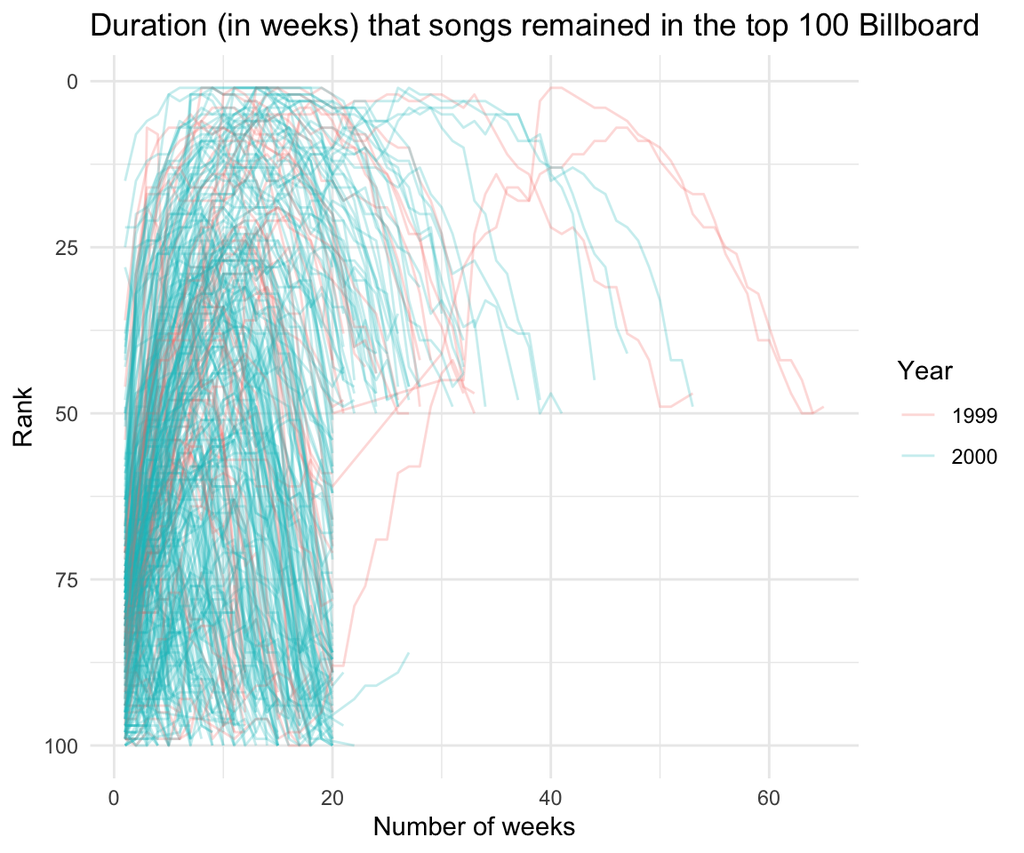

- Wie viele Wochen war ein Lied am längsten in den Top 100?
- Warum ist 100 unten und 0 oben?
- Warum ist das untere rechte Viertel leer? Was bedeutet das?

**Aufgabe 1: Tidy data**

**Beispiel 2**

1. Erstellt Abbildung 2 neu.

# 5 Widening data: `df_cms`

- `pivot_wider()` macht Datensätze *breiter*, indem es Spalten vergrößert und Zeilen verkleinert
  - Dies ist hilfreich, wenn eine Beobachtung über mehrere Zeilen verteilt ist.
  - Diese Art von Daten ist in der freien Wildbahn nicht sehr häufig, aber in Regierungsdaten ist sie ziemlich verbreitet.
- der Datensatz `cms_patient_experience.csv` enthält Daten über Patientenerfahrungen von den Centers of Medicare and Medicaid Services
- die untersuchte Kerneinheit ist eine Organisation (gespeichert in `org_pac_id` und `org_nm`), aber jede Organisation (d.h. Beobachtung) nimmt 6 Zeilen ein
  - eine Zeile für jede Maßnahme (d. h. Variable)
  - Wir wollen also, dass diese Variablen in Spalten dargestellt werden

| org_pac_id | org_nm | measure_cd | measure_title | prf_rate |
| --- | --- | --- | --- | --- |
| 0446157747 | USC CARE MEDICAL GROUP INC | CAHPS_GRP_1 | CAHPS for MIPS SSM: Getting Timely Care, Appointments, and Information | 63 |
| 0446157747 | USC CARE MEDICAL GROUP INC | CAHPS_GRP_2 | CAHPS for MIPS SSM: How Well Providers Communicate | 87 |
| 0446157747 | USC CARE MEDICAL GROUP INC | CAHPS_GRP_3 | CAHPS for MIPS SSM: Patient's Rating of Provider | 86 |
| 0446157747 | USC CARE MEDICAL GROUP INC | CAHPS_GRP_5 | CAHPS for MIPS SSM: Health Promotion and Education | 57 |
| 0446157747 | USC CARE MEDICAL GROUP INC | CAHPS_GRP_8 | CAHPS for MIPS SSM: Courteous and Helpful Office Staff | 85 |
| 0446157747 | USC CARE MEDICAL GROUP INC | CAHPS_GRP_12 | CAHPS for MIPS SSM: Stewardship of Patient Resources | 24 |

## 5.1 `pivot_wider()`

- nimmt lange Daten und macht sie breiter
- benötigt einige Argumente:
  - `id_cols`: identifizierende Spalten
  - `names_from`: wie soll die neue Spalte heißen, die die bisherigen Spaltennamen enthält?
  - `names_prefix`: Präfix für die neuen Spaltennamen
  - `values_from`: neue Spaltenwerte
- Wie können wir für jede `org`,
  - die sechs Werte aus `measure_cd` nehmen und sechs neue Variablen `names` daraus erstellen,
  - und die `values` aus `prf_rate` nehmen?
- das Ergebnis sollte wie Tabelle 5 aussehen

```r
cms_patient_experience %>%
  pivot_wider(
    id_cols = starts_with("org"),
    names_from = measure_cd,
    values_from = prf_rate
  ) %>%
  head() %>%
  knitr::kable() %>%
  kableExtra::kable_styling(font_size = 20)
```

Tabelle 5: Wider `df_cms` data (measure variable to columns with rating as values)

| org_pac_id | org_nm | CAHPS_GRP_1 | CAHPS_GRP_2 | CAHPS_GRP_3 | CAHPS_GRP_5 | CAHPS_GRP_8 | CAHPS_GRP_12 |
| --- | --- | --- | --- | --- | --- | --- | --- |
| 0446157747 | USC CARE MEDICAL GROUP INC | 63 | 87 | 86 | 57 | 85 | 24 |
| 0446162697 | ASSOCIATION OF UNIVERSITY PHYSICIANS | 59 | 85 | 83 | 63 | 88 | 22 |
| 0547164295 | BEAVER MEDICAL GROUP PC | 49 | NA | 75 | 44 | 73 | 12 |
| 0749333730 | CAPE PHYSICIANS ASSOCIATES PA | 67 | 84 | 85 | 65 | 82 | 24 |
| 0840104360 | ALLIANCE PHYSICIANS INC | 66 | 87 | 87 | 64 | 87 | 28 |
| 0840109864 | REX HOSPITAL INC | 73 | 87 | 84 | 67 | 91 | 30 |

- Tabelle 6 zeigt die ersten 6 Zeilen des Originaldatensatzes

Tabelle 6: Original `cms_patient_experience.csv` format

| org_pac_id | org_nm | measure_cd | measure_title | prf_rate |
| --- | --- | --- | --- | --- |
| 0446157747 | USC CARE MEDICAL GROUP INC | CAHPS_GRP_1 | CAHPS for MIPS SSM: Getting Timely Care, Appointments, and Information | 63 |
| 0446157747 | USC CARE MEDICAL GROUP INC | CAHPS_GRP_2 | CAHPS for MIPS SSM: How Well Providers Communicate | 87 |
| 0446157747 | USC CARE MEDICAL GROUP INC | CAHPS_GRP_3 | CAHPS for MIPS SSM: Patient's Rating of Provider | 86 |
| 0446157747 | USC CARE MEDICAL GROUP INC | CAHPS_GRP_5 | CAHPS for MIPS SSM: Health Promotion and Education | 57 |
| 0446157747 | USC CARE MEDICAL GROUP INC | CAHPS_GRP_8 | CAHPS for MIPS SSM: Courteous and Helpful Office Staff | 85 |
| 0446157747 | USC CARE MEDICAL GROUP INC | CAHPS_GRP_12 | CAHPS for MIPS SSM: Stewardship of Patient Resources | 24 |

- Tabelle 7 zeigt die ersten 6 Zeilen des erweiterten Datensatzes

Tabelle 7: Widened `cms_patient_experience.csv` format

| org_pac_id | org_nm | CAHPS_GRP_1 | CAHPS_GRP_2 | CAHPS_GRP_3 | CAHPS_GRP_5 | CAHPS_GRP_8 | CAHPS_GRP_12 |
| --- | --- | --- | --- | --- | --- | --- | --- |
| 0446157747 | USC CARE MEDICAL GROUP INC | 63 | 87 | 86 | 57 | 85 | 24 |
| 0446162697 | ASSOCIATION OF UNIVERSITY PHYSICIANS | 59 | 85 | 83 | 63 | 88 | 22 |
| 0547164295 | BEAVER MEDICAL GROUP PC | 49 | NA | 75 | 44 | 73 | 12 |
| 0749333730 | CAPE PHYSICIANS ASSOCIATES PA | 67 | 84 | 85 | 65 | 82 | 24 |
| 0840104360 | ALLIANCE PHYSICIANS INC | 66 | 87 | 87 | 64 | 87 | 28 |
| 0840109864 | REX HOSPITAL INC | 73 | 87 | 84 | 67 | 91 | 30 |

- Wie werden die Daten aus Tabelle 6 in Tabelle 7 dargestellt?

# 6 Aufgabe

1. Durchsucht die Titel. Wählt einen Titel, der euch gefällt (oder einen zufälligen Titel), und dann
   - filtert die Daten so, dass sie nur diesen Titel enthalten, und dann
   - Erstellt ein Liniendiagramm der Zeit des Liedes in den Top 100 Billboard
   - Bezieht sich auf das Diagramm und beschreibt den Trend des Liedes (dazu solltet euch die Daten des Liedes ansehen).

Ein Beispiel: *Abbildung 3 zeigt den Trend von ‘Say My Name’ von Destiny’s Child, das am 25. Dezember 1999 (`date_entered`) auf Platz 83 (`rank` für `wk1`) in die Charts einstieg und 32 Wochen lang in den Top 100 blieb (z.b., `max(week)`).*

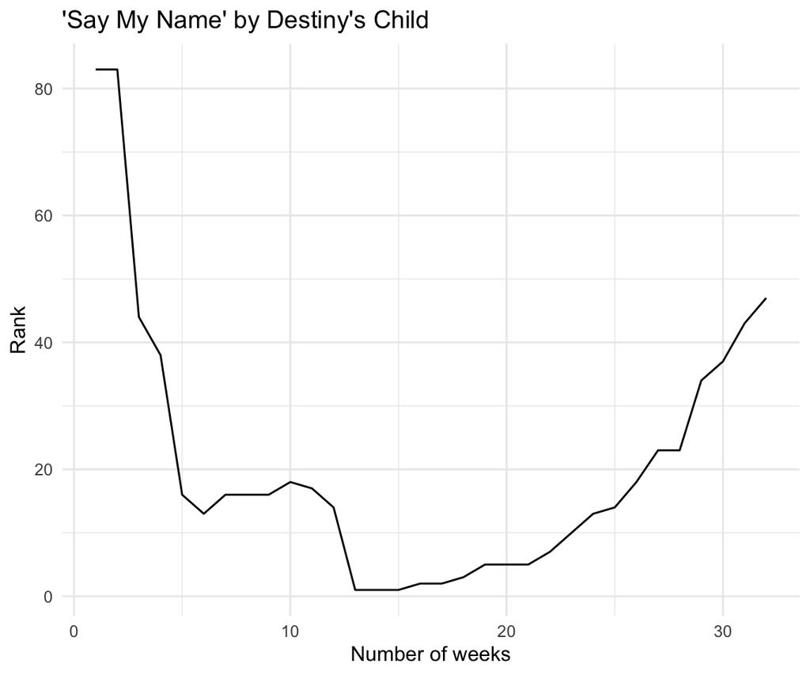

Abbildung 3: Example linegraph for ‘Say My Name’ by Destiny’s Child

2. Lädt den Datensatz `biondo_etal_2021_tidy.csv` (Teilmenge der Daten von Biondo et al. (2022)) und speichert ihn als `df_biondo`
- druckt eine formatierte Tabelle (mit `knitr::kable()`) mit einem `Label` und einer Beschriftung des `Kopfes()` der Daten
3. Verlängere die Daten so, dass die Spalten `rt` und `tt` in einer Spalte stehen:
   - Die Variable `Namen` sollte in eine neue Variable mit dem Namen `Maß` übergehen.
   - Die Variable “Werte” geht in eine neue Variable “ms” (für Millisekunden) über.
   - Speichern der verlängerten Daten als `df_biondo_long`
- druckt eine formatierte Tabelle (mit `knitr::kable()`) mit einem `Label` und einer Beschriftung
4. Erweitert `df_biondo_long` so, dass die Spalten `rt` und `tt` wieder in ihren eigenen Spalten sind
   - die `id_cols` sollten `subj` und `item` sein
   - die Variable `Namen` sollte `von` `Maß` kommen
   - die Variable `values` sollte von `ms` (für Millisekunden) stammen
   - die verlängerten Daten als `df_biondo_wide` speichern
   - eine formatierte Tabelle (mit `knitr::kable()`) mit einem `Label` und einer Beschriftung ausgeben
   - Tipp: `df_biondo_wide` sollte genau dasselbe sein wie `df_biondo`.

# Heutige Ziele 🏁

Heute haben wir…

- etwas über breite und lange Daten lernen ✅
- breite Daten länger machen ✅
- lange Daten breiter machen ✅

# Session Info

Hergestellt mit R version 4.3.0 (2023-04-21) (Already Tomorrow) und RStudioversion 2023.3.0.386 (Cherry Blossom).

# Literaturverzeichnis

Biondo, N., Soilemezidi, M., & Mancini, S. (2022). Yesterday Is History, Tomorrow Is a Mystery: An Eye-Tracking Investigation of the Processing of Past and Future Time Reference during Sentence Reading. *Journal of Experimental Psychology: Learning, Memory, and Cognition*, *48*(7), 1001–1018. https://doi.org/10.1037/xlm0001053

Nordmann, E., & DeBruine, L. (2022). *Applied Data Skills* (Version 2.0). Zenodo. https://doi.org/10.5281/zenodo.6365078

Wickham, H., Çetinkaya-Rundel, M., & Grolemund, G. (o. J.). *R for Data Science* (2. Aufl.). https://r4ds.hadley.nz/